# Module 3 Solutions

## Data set-up

See Module 1 Solutions for recommendations on how to import data.

The following packages were used for the solutions.

````markdown
```{r}
# Load libraries
library(tidyverse) # for data manipulation
library(skimr) # for skim() to summarise datasets
library(labelled) # for generate_dictionary() to view value labels
library(janitor) # for tabyl() to create frequency tables
library(lubridate) # for working with date variables
```
````

We import the data as below.

```r
# Import data from Github ----
## Read in csv file
ppn_subset_2000 <- read_csv("https://raw.githubusercontent.com/NicoleDeLaMata/LinkedData/refs/heads/main/ppn_subset_2000.csv")
```

## Part One: Prevalent Pool Effect

## Question 1

```r
## Convert date variables to date format then sort the data
ppn_subset_2000 <- ppn_subset_2000 %>%
  mutate(episode_start_date = dmy(episode_start_date),
         episode_end_date = dmy(episode_end_date)) %>%
  arrange(ppn, episode_start_date, episode_end_date)

## Attach labels to mode_of_separation
ppn_subset_2000$mode_of_separation_recode <- factor(ppn_subset_2000$mode_of_separation_recode,
                                                    levels = c(seq(0,11,1)),
                                                    labels = c("Discharge on leave", "Discharge by hospital",
                                                  "Discharge own risk", "Transfer to nursing home",
                                                  "Transfer to public psychiatric hospital", "Transfer to other hospital",
                                                  "Death with autopsy", "Death without autopsy",
                                                  "Transfer to other accommodation", "Type change separation",
                                                  "Discharge on leave", "Transfer to palliative care unit/hospice"))

## Create a flag for patients with any admissions related to ischemic heart disease
diag_vars <- paste0("diagnosis_code", c("P", seq(1, 19)))
diag_vars
```

```
 [1] "diagnosis_codeP"  "diagnosis_code1"  "diagnosis_code2"  "diagnosis_code3"
 [5] "diagnosis_code4"  "diagnosis_code5"  "diagnosis_code6"  "diagnosis_code7"
 [9] "diagnosis_code8"  "diagnosis_code9"  "diagnosis_code10" "diagnosis_code11"
[13] "diagnosis_code12" "diagnosis_code13" "diagnosis_code14" "diagnosis_code15"
[17] "diagnosis_code16" "diagnosis_code17" "diagnosis_code18" "diagnosis_code19"
```

```r
ihd_codes <- c("I20", "I21", "I22", "I24", "I25")

ppn_subset_2000 <- ppn_subset_2000 %>%
  mutate(ihd = 1 * if_any(all_of(diag_vars), ~ str_sub(.x, 1, 3) %in% ihd_codes))

## Create a one-way frequency table of ihd to check that flag has been created correctly
ppn_subset_2000 %>% tabyl(ihd)
```

```
 ihd     n   percent
   0 65314 0.8112331
   1 15198 0.1887669
```

There should be 15,198 records coded with ischemic heart disease events  
## Question 2

1. Create a frequency table of *year_sep* against flag variable ihd. How many acute cardiovascular events occurred in 2002?

```r
## Create a variable for year of separation
ppn_subset_2000 <- ppn_subset_2000 %>% mutate(year_sep = year(episode_end_date))

## Frequency table of year_sep against ihd
ppn_subset_2000 %>%
  tabyl(year_sep, ihd) %>%
  adorn_percentages(denominator = "row") %>%
  adorn_pct_formatting(digits = 0) %>%
  adorn_ns(position = "front")
```

```
 year_sep           0           1
     2000 1,309 (56%) 1,021 (44%)
     2001 2,981 (74%) 1,069 (26%)
     2002 4,169 (77%) 1,245 (23%)
     2003 4,334 (83%)   903 (17%)
     2004 4,237 (83%)   846 (17%)
     2005 4,262 (81%) 1,018 (19%)
     2006 5,056 (86%)   823 (14%)
     2007 4,436 (86%)   736 (14%)
     2008 2,996 (87%)   433 (13%)
     2009 3,038 (88%)   411 (12%)
     2010 3,176 (79%)   834 (21%)
     2011 2,590 (80%)   658 (20%)
     2012 3,181 (87%)   473 (13%)
     2013 2,841 (84%)   531 (16%)
     2014 2,694 (84%)   532 (16%)
     2015 2,987 (83%)   631 (17%)
     2016 2,981 (82%)   667 (18%)
     2017 2,289 (79%)   625 (21%)
     2018 2,102 (79%)   563 (21%)
     2019 2,145 (76%)   687 (24%)
     2020 1,510 (75%)   492 (25%)
```

1,245 episodes of care related to IHD in 2002 (23% of all episodes of care in 2002)

2. Why do we use year of separation rather than year of admission?  
   We use year of separation, not admission, because that is how records are processed within the hospital morbidity system. That is, each record is coded after separation and classified by financial year based on the date of separation.

## Question 3

1. Create and tabulate *ihd_seq*.

```r
## Create IHD seq
ppn_subset_2000 <- ppn_subset_2000 %>%
  group_by(ppn) %>%
  mutate(ihd_cumcount = cumsum(ihd), # cumulative total number of IHD records for each person
         post_ihd = as.numeric(ihd_cumcount > 0)) %>% # Flag records that occur on or after first IHD
  group_by(ppn, post_ihd) %>%
  mutate(ihd_seq = row_number() * post_ihd) %>% # If prior to first IHD, seq = 0, otherwise seq = row number
  ungroup()

## Create table of ihd_seq to check
ppn_subset_2000 %>% tabyl(ihd_seq)
```

```
 ihd_seq     n      percent
       0 38042 4.725010e-01
       1  8746 1.086298e-01
       2  7410 9.203597e-02
       3  6209 7.711894e-02
       4  5038 6.257452e-02
       5  3961 4.919764e-02
       6  2897 3.598221e-02
       7  1990 2.471681e-02
       8  1274 1.582373e-02
       9   798 9.911566e-03
      10   486 6.036367e-03
      11   276 3.428060e-03
      12   189 2.347476e-03
      13   125 1.552564e-03
```

[output cut: 538 more lines]

```r
ppn_subset_2000 %>% skim(ihd_seq) # Maximum (p100) is 551
```

Data summary

| Name | Piped data |
| --- | --- |
| Number of rows | 80512 |
| Number of columns | 54 |
| _______________________ |  |
| Column type frequency: |  |
| numeric | 1 |
| ________________________ |  |
| Group variables | None |

**Variable type: numeric**

| skim_variable | n_missing | complete_rate | mean | sd | p0 | p25 | p50 | p75 | p100 | hist |
| --- | --- | --- | --- | --- | --- | --- | --- | --- | --- | --- |
| ihd_seq | 0 | 1 | 5.84 | 30.81 | 0 | 0 | 1 | 3 | 551 | ▇▁▁▁▁ |

2. Produce a table containing the number of first hospital admissions with ischemic heart disease event (*ihd_seq* = 1) by year of separation.

```r
## Create and save a table of year of separation for first IHD hospital admissions
ihd_year_table_2000 <- ppn_subset_2000 %>%
  filter(ihd_seq == 1) %>%
  tabyl(year_sep) %>%
  as_tibble()

ihd_year_table_2000 %>% filter(year_sep == 2010)
```

```
# A tibble: 1 × 3
  year_sep     n percent
     <dbl> <int>   <dbl>
1     2010   410  0.0469
```

## Question 4

```r
## restrict data to 2008-2020
ppn_subset_2008 <- ppn_subset_2000 %>% filter(year_sep >= 2008)

## Create IHD seq
ppn_subset_2008 <- ppn_subset_2008 %>%
  group_by(ppn) %>%
  mutate(ihd_cumcount = cumsum(ihd), # cumulative total number of IHD records for each person
         post_ihd = as.numeric(ihd_cumcount > 0)) %>% # Flag records that occur on or after first IHD
  group_by(ppn, post_ihd) %>%
  mutate(ihd_seq = row_number() * post_ihd) %>% # If prior to first IHD, seq = 0, otherwise seq = row number
  ungroup()

## Create table of ihd_seq to check
ppn_subset_2008 %>% tabyl(ihd_seq)
```

```
 ihd_seq     n      percent
       0 26792 6.368888e-01
       1  5537 1.316234e-01
       2  3687 8.764590e-02
       3  2298 5.462714e-02
       4  1312 3.118834e-02
       5   679 1.614092e-02
       6   335 7.963487e-03
       7   167 3.969858e-03
       8    97 2.305845e-03
       9    69 1.640241e-03
      10    57 1.354981e-03
      11    53 1.259895e-03
      12    51 1.212352e-03
      13    46 1.093494e-03
```

[output cut: 160 more lines]

```r
ppn_subset_2008 %>% skim(ihd_seq) # Maximum (p100) is 173
```

Data summary

| Name | Piped data |
| --- | --- |
| Number of rows | 42067 |
| Number of columns | 54 |
| _______________________ |  |
| Column type frequency: |  |
| numeric | 1 |
| ________________________ |  |
| Group variables | None |

**Variable type: numeric**

| skim_variable | n_missing | complete_rate | mean | sd | p0 | p25 | p50 | p75 | p100 | hist |
| --- | --- | --- | --- | --- | --- | --- | --- | --- | --- | --- |
| ihd_seq | 0 | 1 | 1.9 | 9.11 | 0 | 0 | 0 | 1 | 173 | ▇▁▁▁▁ |

```r
## Create and save a table of year of separation for first IHD hospital admissions
ihd_year_table_2008 <- ppn_subset_2008 %>%
  filter(ihd_seq == 1) %>%
  tabyl(year_sep) %>%
  as_tibble()
```

## Question 5

```r
## restrict data to 2010-2020
ppn_subset_2010 <- ppn_subset_2000 %>% filter(year_sep >= 2010)

## Create IHD seq
ppn_subset_2010 <- ppn_subset_2010 %>%
  group_by(ppn) %>%
  mutate(ihd_cumcount = cumsum(ihd), # cumulative total number of IHD records for each person
         post_ihd = as.numeric(ihd_cumcount > 0)) %>% # Flag records that occur on or after first IHD
  group_by(ppn, post_ihd) %>%
  mutate(ihd_seq = row_number() * post_ihd) %>% # If prior to first IHD, seq = 0, otherwise seq = row number
  ungroup()

## Create table of ihd_seq to check
ppn_subset_2010 %>% tabyl(ihd_seq)
```

```
 ihd_seq     n      percent
       0 22267 6.327830e-01
       1  5061 1.438234e-01
       2  3170 9.008497e-02
       3  1858 5.280059e-02
       4   971 2.759385e-02
       5   480 1.364063e-02
       6   234 6.649805e-03
       7   106 3.012305e-03
       8    66 1.875586e-03
       9    51 1.449317e-03
      10    45 1.278809e-03
      11    42 1.193555e-03
      12    40 1.136719e-03
      13    36 1.023047e-03
```

[output cut: 155 more lines]

```r
ppn_subset_2010 %>% skim(ihd_seq) # Maximum (p100) is 168
```

Data summary

| Name | Piped data |
| --- | --- |
| Number of rows | 35189 |
| Number of columns | 54 |
| _______________________ |  |
| Column type frequency: |  |
| numeric | 1 |
| ________________________ |  |
| Group variables | None |

**Variable type: numeric**

| skim_variable | n_missing | complete_rate | mean | sd | p0 | p25 | p50 | p75 | p100 | hist |
| --- | --- | --- | --- | --- | --- | --- | --- | --- | --- | --- |
| ihd_seq | 0 | 1 | 1.93 | 9.43 | 0 | 0 | 0 | 1 | 168 | ▇▁▁▁▁ |

```r
## Create and save a table of year of separation for first IHD hospital admissions
ihd_year_table_2010 <- ppn_subset_2010 %>%
  filter(ihd_seq == 1) %>%
  tabyl(year_sep) %>%
  as_tibble()
```

## Question 6

Produce a line graph of the annual number of incident cases of ischemic heart disease events from 2010-2020 based on the three datasets you used above.

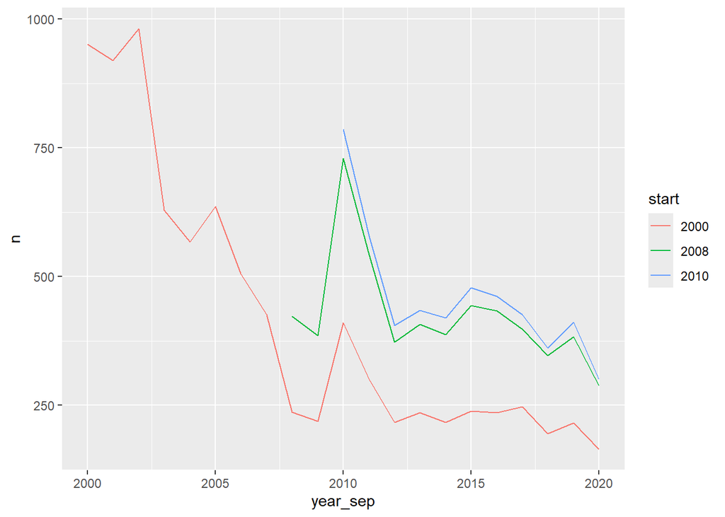

```r
## Basic line graph
plotdata <- bind_rows(
  ihd_year_table_2000 %>% mutate(start = "2000"), # make start year a character not a number, to force R to recognise it as categorical not continuous
  ihd_year_table_2008 %>% mutate(start = "2008"),
  ihd_year_table_2010 %>% mutate(start = "2010"))

## Quick plot to see trends
ggplot(data = plotdata) +
  geom_line(aes(x = year_sep, y = n, colour = start))
```

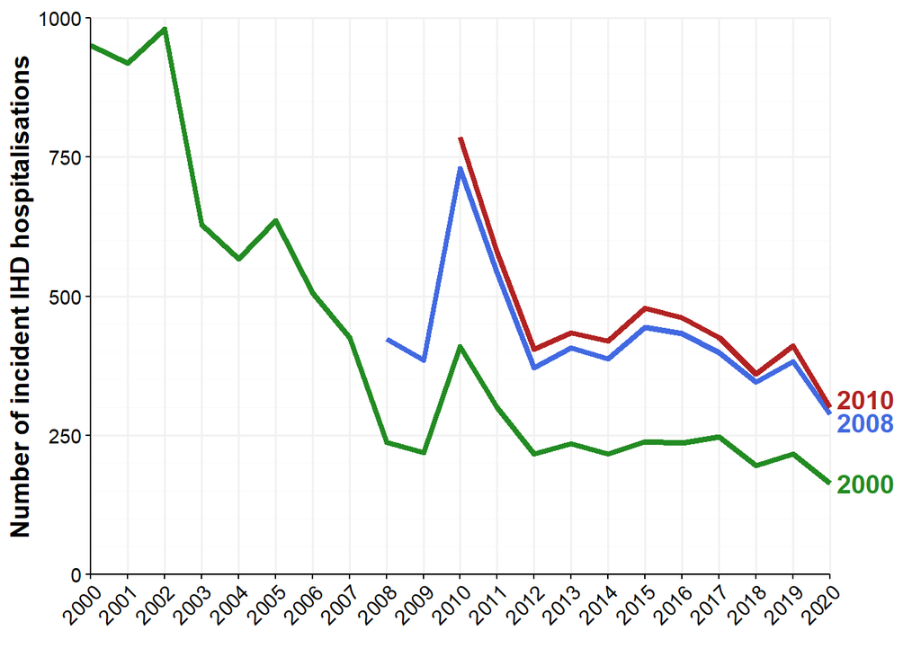

```r
## Nicer looking plot (if interested)
ggplot(data = plotdata, mapping = aes(x = year_sep, y = n)) +
  geom_line(aes(colour = start),
            linewidth = 1.5) +
  geom_text(data = plotdata %>% group_by(start) %>% slice(n()),
            aes(label = start, colour = start),
            size = 5, fontface = "bold", hjust = 0, nudge_x = 0.2, nudge_y = c(0, -15, 15)) +
  xlab("") +
  ylab("Number of incident IHD hospitalisations") +
  coord_cartesian(xlim = c(2000, 2020),
                  ylim = c(0, 1000),
                  clip = "off") +
  scale_x_continuous(breaks = 2000:2020,
                     minor_breaks = NULL,
                     expand = c(0, 0)) +
  scale_y_continuous(breaks = seq(0, 1000, 250),
                     minor_breaks = seq(0, 1000, 50),
                     expand = c(0, 0)) +
  scale_colour_manual(values = c("2000" = "forestgreen",
                                 "2008" = "royalblue",
                                 "2010" = "firebrick")) +
  theme_minimal() +
  theme(axis.text = element_text(colour = "black", size = 11),
        axis.title = element_text(colour = "black", size = 14, face = "bold"),
        axis.line = element_line(colour = "black"),
        axis.ticks = element_line(colour = "black"),
        axis.text.x = element_text(angle = 45, hjust = 1),
        legend.position = "none",
        panel.grid.major = element_line(colour = "grey95", linewidth = 0.7),
        panel.grid.minor = element_line(colour = "grey98", linewidth = 0.1),
        panel.border = element_blank(),
        plot.margin = margin(t = 10, b = 0, l = 5, r = 50))
```

1. What do you notice about the frequencies compared between the three datasets?  
   Frequencies are higher when starting the analysis in more recent years. This is because we are incorrectly counting IHD hospitalisations as incident IHD, when in fact there was a historical IHD hospitalisation earlier than the start of our analysis dataset.
2. Do you think a 4-year clearance period would be sufficient for obtaining an accurate estimate of incident cases in 2010? In the full analysis dataset (2000-2020), the number of incident IHD hospitalisations is initially high (due to the prevalent pool effect) but reaches a steady state after about 7-8 years. A 4-year clearance period would probably not be sufficient to accurately estimate incident IHD hospitalisations.

## Part Two: Transfers and Length of Stay

## Question 7

Define how you would appropriately construct a study population with all the available hospitalisation data to determine length of stay for ischemic heart disease patients. Consider what records should be included. What important assumptions have we made in constructing this study population?  
**Steps for constructing the study population:**

1. Determine which episodes of care were part of the same hospital admission.

2. Flag any hospital admissions where any diagnosis code within any episode of care was related to IHD.

3. Remove episodes of care if there was no IHD flagged for the entire hospital admission.

4. Calculate length of stay for each hospital admission (latest episode end date minus earliest episode start date).

5. Collapse the dataset to one row per person per IHD hospital admission, keeping the length of stay for each admission.

**Assumptions:**

1. Hospital admissions are for ischemic heart disease even if the primary diagnosis code was unrelated.

2. For hospital admissions where ischemic heart disease was diagnosed partway through, we are assuming the entire length of stay was attributable to ischemic heart disease.

3. All transfers have been accounted for correctly, and there were no interstate transfers.

## Question 8

1. Looking at observations relating to ppn “34” and year of separation = 2005. Which episodes of care have overlapping dates and how many total hospital admissions did this person have?

```r
## Observations for ppn 34 and year of separation 2005
ppn_subset_2000 %>%
  filter(ppn == 34 & year_sep==2005) %>%
  select(ppn, episode_start_date, episode_end_date, mode_of_separation_recode) %>%
  print()
```

```
# A tibble: 6 × 4
    ppn episode_start_date episode_end_date mode_of_separation_recode
  <dbl> <date>             <date>           <fct>
1    34 2005-05-28         2005-05-28       Discharge by hospital
2    34 2005-08-10         2005-08-17       Discharge by hospital
3    34 2005-09-12         2005-09-12       Discharge by hospital
4    34 2005-09-12         2005-09-15       Discharge by hospital
5    34 2005-10-26         2005-10-26       Transfer to other hospital
6    34 2005-10-26         2005-10-31       Discharge by hospital
```

PPN 34 (2005) = 6 episodes, 5 admissions:

- #3 and #4 overlap (#3 end date is same as #4 start date). But they are two separate admissions. #3 is a single-day admission, #4 is an entirely new admission

- #5 and #6 overlap (#5 end date is same as #6 start date). #5 ends with a transfer, so these are both part of the same admission.

2. Looking at observations relating to ppn “62” and year of separation = 2007. Which episodes of care have overlapping dates and how many total hospital admissions did this person have?

```r
## Observations for ppn 62 and year of separation 2007
ppn_subset_2000 %>%
  filter(ppn == 62 & year_sep==2007) %>%
  select(ppn, episode_start_date, episode_end_date, mode_of_separation_recode) %>%
  print()
```

```
# A tibble: 6 × 4
    ppn episode_start_date episode_end_date mode_of_separation_recode
  <dbl> <date>             <date>           <fct>
1    62 2007-02-11         2007-02-19       Transfer to other hospital
2    62 2007-02-19         2007-02-19       Discharge by hospital
3    62 2007-02-19         2007-02-28       Discharge by hospital
4    62 2007-03-14         2007-03-16       Discharge by hospital
5    62 2007-08-20         2007-08-20       Discharge by hospital
6    62 2007-10-07         2007-11-10       Discharge by hospital
```

PPN 62 (2007) = 6 episodes, 5 admissions

- #1, #2, and #3 overlap (#1 end date is same as #2 start date, and #2 end date is same as #3 start date)

- #1 ends with a transfer, so #1 and #2 are both part of the same admission

- #2 ends with a discharge, so #2 and #3 are different admissions.

3. Looking at observations relating to ppn “216” and year of separation = 2010. Which episodes of care have overlapping dates and how many total hospital admissions did this person have?

```r
## Observations for ppn 216 and year of separation 2010
ppn_subset_2000 %>%
  filter(ppn == 216 & year_sep==2010) %>%
  select(ppn, episode_start_date, episode_end_date, mode_of_separation_recode) %>%
  print()
```

```
# A tibble: 7 × 4
    ppn episode_start_date episode_end_date mode_of_separation_recode
  <dbl> <date>             <date>           <fct>
1   216 2010-01-31         2010-02-09       Discharge by hospital
2   216 2010-02-21         2010-02-21       Transfer to other hospital
3   216 2010-02-26         2010-02-26       Transfer to other hospital
4   216 2010-02-26         2010-02-26       Discharge by hospital
5   216 2010-02-26         2010-03-02       Discharge by hospital
6   216 2010-04-03         2010-04-13       Discharge by hospital
7   216 2010-07-18         2010-07-20       Discharge by hospital
```

PPN 216 (2010) = 7 episodes, 6 admissions

- #3, #4, and #5 overlap (#3 end = #4 start, #4 end = #5 start)

- #3 ends with a transfer, so #3 and #4 are part of the same admission

- #4 ends with a discharge, so #4 and #5 are different admissions

- #2 ends with a transfer, but none of the other records have dates that align, so this possibly an interstate transfer, or an error

4. Looking at observations relating to ppn “286” and year of separation = 2003. Which episodes of care have overlapping dates and how many total hospital admissions did this person have?

```r
## Observations for ppn 286 and year of separation 2003
ppn_subset_2000 %>%
  filter(ppn == 286 & year_sep==2003) %>%
  select(ppn, episode_start_date, episode_end_date, mode_of_separation_recode) %>%
  print()
```

```
# A tibble: 6 × 4
    ppn episode_start_date episode_end_date mode_of_separation_recode
  <dbl> <date>             <date>           <fct>
1   286 2002-12-28         2003-01-03       Discharge by hospital
2   286 2003-01-13         2003-01-18       Discharge by hospital
3   286 2003-03-22         2003-03-22       Transfer to other hospital
4   286 2003-03-22         2003-04-10       Transfer to other hospital
5   286 2003-03-24         2003-03-25       Transfer to other hospital
6   286 2003-04-10         2003-04-13       Death without autopsy
```

PPN 286 (2003) = 6 episodes, 3 admissions

- #3, #4, #5, and #6 all overlap (#3 end = #4 start, #4 end = #6 start, and #5 starts and ends in between #4 start and end)

- #3 ends with a transfer, so #3 and #4 are part of the same admission

- #5 ends with a transfer, so #5 is entirely within #4 (i.e. a nested transfer)

- #4 ends with a transfer, so #4 and #6 are part of the same admission

5. What further information would be helpful in deciding which transfers align to the same hospital admission?

It would be helpful to know:

- The time of day of each episode start and end, to decide whether episodes of care on the same day that end in discharge are genuinely separate admissions or if this is an error and they should be part of the same admission.

- How each episode started (‘mode of admission’) to determine if the patient was transferred from elsewhere or was a new admission.

- The hospital where each episode of care took place, and the hospital that the patient was transferred from and to.

## Question 9

Define the data processing steps that would be necessary to identify and group together the episodes of care to reflect the same hospitalisation admission.  
If an episode of care is nested within another episode of care, it must be part of the same admission. We would take the earliest episode start date and latest episode end date to define the admission

If an episode starts on the same day that another ends, we would need to check the mode of separation, as well as the facility code, facility transferred from, and facility transferred to. Then we can determine which episode end date would be most appropriate

If an episode of care does not have overlapping dates with another episode of care, they are two separate admissions and each episode start date and end date can be used respectively.

## Question 10

Apply the provided transfers code *transfers()* to add variables to your dataset to identify which episodes of care belong to the same hospital admission. Identify the number of transfers (including type changes):

```r
## Load transfers package
library(devtools)
install_github("james-hedley/transfers")
```

```
WARNING: Rtools is required to build R packages, but is not currently installed.

Please download and install Rtools 4.4 from https://cran.r-project.org/bin/windows/Rtools/.
```

```
Skipping install of 'transfers' from a github remote, the SHA1 (2f69320d) has not changed since last install.
  Use `force = TRUE` to force installation
```

```r
library(transfers)

## Identify transfers in the analysis dataset
ppn_subset_2000 <- ppn_subset_2000 %>%
  transfers(id = "ppn",
                admdate = "episode_start_date",
                sepdate = "episode_end_date",
                mode = "mode_of_separation_recode")
```

1. How many periods of stay contained one or more transfers? What is the maximum number of transfers?

```r
## Check transseq
ppn_subset_2000 %>% tabyl(transseq)
```

```
 transseq     n      percent
        0 79583 9.884613e-01
        1   551 6.843700e-03
        2    91 1.130266e-03
        3    58 7.203895e-04
        4    45 5.589229e-04
        5    37 4.595588e-04
        6    28 3.477742e-04
        7    25 3.105127e-04
        8    23 2.856717e-04
        9    16 1.987281e-04
       10    10 1.242051e-04
       11     9 1.117846e-04
       12     6 7.452305e-05
       13     6 7.452305e-05
       14     5 6.210254e-05
       15     5 6.210254e-05
       16     4 4.968203e-05
       17     4 4.968203e-05
       18     2 2.484102e-05
       19     2 2.484102e-05
       20     2 2.484102e-05
```

2. Examine a portion of the dataset to check that you have identified transfers correctly.

```r
## Check PPN 286 as an example
ppn_subset_2000 %>%
  filter(ppn == 286) %>%
  select(ppn, episode_start_date, episode_end_date, mode_of_separation_recode, stayseq, transseq, totlos) %>%
  print()
```

```
# A tibble: 34 × 7
     ppn episode_start_date episode_end_date mode_of_separation_recode  stayseq
   <dbl> <date>             <date>           <fct>                        <dbl>
 1   286 2000-08-29         2000-08-29       Discharge by hospital            1
 2   286 2000-11-07         2000-11-07       Discharge by hospital            2
 3   286 2001-01-09         2001-01-15       Discharge by hospital            3
 4   286 2001-03-28         2001-03-30       Discharge by hospital            4
 5   286 2001-05-16         2001-05-16       Discharge by hospital            5
 6   286 2001-05-22         2001-05-22       Transfer to other hospital       6
 7   286 2001-05-22         2001-05-26       Discharge by hospital            7
 8   286 2001-05-25         2001-05-25       Transfer to other hospital       7
 9   286 2001-05-30         2001-06-01       Transfer to other hospital       8
10   286 2001-06-01         2001-06-07       Transfer to other hospital       9
# ℹ 24 more rows
# ℹ 2 more variables: transseq <dbl>, totlos <drtn>
```

We checked PPN 286 as an example.

## Question 11

Using all the available data in the data set, create a data set containing only records relating to ischemic heart disease events.

```r
## Create analysis dataset restricted to episodes of care related to IHD
analysis_data <- ppn_subset_2000 %>%
  filter(ihd == 1)
```

## Question 12

Calculate the mean length of stay by:

1. ignoring transfers (i.e., assume each episode of care is a separate hospital admission, with transfers representing a ‘new’ admission).

```r
## Mean LOS ignoring transfers
analysis_data %>%
  mutate(los = as.numeric(episode_end_date - episode_start_date)) %>%
  skim(los)
```

Data summary

| Name | Piped data |
| --- | --- |
| Number of rows | 15198 |
| Number of columns | 63 |
| _______________________ |  |
| Column type frequency: |  |
| numeric | 1 |
| ________________________ |  |
| Group variables | None |

**Variable type: numeric**

| skim_variable | n_missing | complete_rate | mean | sd | p0 | p25 | p50 | p75 | p100 | hist |
| --- | --- | --- | --- | --- | --- | --- | --- | --- | --- | --- |
| los | 0 | 1 | 6.49 | 11.1 | 0 | 0 | 0 | 10 | 129 | ▇▁▁▁▁ |

Ignoring transfers and counting each episode of care: Mean = 6.49 days

2. accounting for transfers (i.e., where all episodes of care for a single hospital admission have been linked)

```r
## Mean LOS accounting for transfers (count each admission once)
analysis_data %>%
  group_by(ppn, stayseq) %>%
  slice(1) %>%
  ungroup() %>%
  mutate(los = as.numeric(totlos)) %>%
  skim(los)
```

Data summary

| Name | Piped data |
| --- | --- |
| Number of rows | 15161 |
| Number of columns | 63 |
| _______________________ |  |
| Column type frequency: |  |
| numeric | 1 |
| ________________________ |  |
| Group variables | None |

**Variable type: numeric**

| skim_variable | n_missing | complete_rate | mean | sd | p0 | p25 | p50 | p75 | p100 | hist |
| --- | --- | --- | --- | --- | --- | --- | --- | --- | --- | --- |
| los | 0 | 1 | 7.22 | 10.98 | 1 | 1 | 1 | 10 | 129 | ▇▁▁▁▁ |

```r
## Mean LOS accounting for transfers (count each episode of care)
analysis_data %>%
  mutate(los = as.numeric(totlos)) %>%
  skim(los)
```

Data summary

| Name | Piped data |
| --- | --- |
| Number of rows | 15198 |
| Number of columns | 63 |
| _______________________ |  |
| Column type frequency: |  |
| numeric | 1 |
| ________________________ |  |
| Group variables | None |

**Variable type: numeric**

| skim_variable | n_missing | complete_rate | mean | sd | p0 | p25 | p50 | p75 | p100 | hist |
| --- | --- | --- | --- | --- | --- | --- | --- | --- | --- | --- |
| los | 0 | 1 | 7.27 | 11.04 | 1 | 1 | 1 | 10 | 129 | ▇▁▁▁▁ |

3. compare these with the mean of the existing APDC variable *episode_length_of_stay*.

```r
## Mean LOS provided
analysis_data %>%
  skim(episode_length_of_stay)
```

Data summary

| Name | Piped data |
| --- | --- |
| Number of rows | 15198 |
| Number of columns | 62 |
| _______________________ |  |
| Column type frequency: |  |
| numeric | 1 |
| ________________________ |  |
| Group variables | None |

**Variable type: numeric**

| skim_variable | n_missing | complete_rate | mean | sd | p0 | p25 | p50 | p75 | p100 | hist |
| --- | --- | --- | --- | --- | --- | --- | --- | --- | --- | --- |
| episode_length_of_stay | 0 | 1 | 6.49 | 11.09 | 0 | 0 | 0 | 10 | 129 | ▇▁▁▁▁ |

Using provided episode_length_of_stay and counting each episode of care: Mean = 6.49 days